# HW2-EDA with R - Part1: Plotting

misken

January 22, 2018

## Step 1 - Familiarize yourself with the data and the assignment

In this assignment you’ll do some exploratory data analysis with R on a dataset US census information based on the [American Community Survey](https://www.census.gov/programs-surveys/acs/). The version of this data that we’ll be using is from a Kaggle dataset. See https://www.kaggle.com/muonneutrino/us-census-demographic-data/data and look at the column metadata for the county level table to see what the various columns mean.

As we did in class, you’ll be creating an R Markdown document to both prepare a dataset and do some analysis as well as to document the steps you did (and answer some questions I’ll throw at you).

You’ll notice a few “Hacker Extra” tasks thrown in. These are for those of you who want to go a little above and beyond and attempt some more challenging tasks. And, feel free to do a some free form Hacker Extra style work yourself - in other words, do something beyond what was asked. You’ll learn more.

## Step 2 - Create a new R Markdown document

Save this file as a new R Markdown document and name it **HW2_EDAwR_[*your last name*].Rmd**. Mine would be called **HW2_EDAwR_isken.Rmd**. Save it into the same folder as this file.

This will be your working directory.

Create a new R Project based on this working directory.

**Hacker Extra** - Put this project folder under version control using git. Only track the .R file, the .Rmd file and your .gitignore file. Create a remote repo for this homework assignment in your GitHub account. Periodically push your commits to GitHub. When done with the assignment, paste in the URL of your GitHub project so that I can go look at it.

## Step 3 - Set working directory and explore data folder

Set the working directory or create an R Studio project in the current folder. You’ll notice that there is a folder named **data**. Inside of it you’ll find the data files for this assignment:

- **acs2015_census_tract_data.csv**
- **acs2015_county_data.csv**
- **us_census_bureau_regions_and_divisions.csv**
- **county.csv**
- **county_MI.csv**

The first two files are from the Kaggle site for this dataset. The two files, **county.csv** and **county_MI.csv**, are files that I created. The first contains county level data from all states and the other just data from Michigan. The R script, **census_data_prep.R** was used to create these files and to merge information from the **us_census_bureau_regions_and_divisions.csv** file with the county data.

You might want to use shell commands or a text editor like Geany to snoop the files a bit.

## Step 4 - Complete the following R tasks and answer questions

Now you’ll need to complete the following tasks in R. Just like we did in class, you should use a combination of markdown text (be concise, no need to write tons of text) to explain what you are doing and R code chunks to actually do it. When you are done, use the “Knit” button to generate an HTML file from your R Markdown. You’ll be submitting BOTH the completed R Markdown file as well as the generated HTML file. You’ll notice that I’ve left some empty code chunks as well as some partially filled in code chunks. Of course, feel free to add more code chunks as needed.

Let’s load a few libraries we’ll need:

```r
library(plyr)
library(dplyr)
```

```r
library(ggplot2)
```

### Problem 1 - Get the data into a dataframe

You should read the **county.csv** file into a data frame named county_df and **county_MI.csv** into a data frame named county_MI.

```r
county_df <- read.csv("~/Documents/hw2_files/data/county.csv")
county_MI <- read.csv("~/Documents/hw2_files/data/county_MI.csv")

#class(county_MI)
#class(county_df)
```

Check the structure of each data.frame and use the `summary` function to begin exploring the data. Are there any NA values? What differences do you notice between the structure of the two data frames.

```r
summary(county_MI)
```

```
##      County   peninsula      State       CensusId     State.Code
##  Alcona : 1   LP:68     Michigan:83   Min.   :26001   MI:83
##  Alger  : 1   UP:15                   1st Qu.:26042
##  Allegan: 1                           Median :26083
##  Alpena : 1                           Mean   :26083
##  Antrim : 1                           3rd Qu.:26124
##  Arenac : 1                           Max.   :26165
##  (Other):77
##      Region                 Division     TotalPop            Men
##  Midwest:83   East North Central:83   Min.   :   2198   Min.   :  1145
##                                       1st Qu.:  22503   1st Qu.: 11152
##                                       Median :  38586   Median : 20843
##                                       Mean   : 119284   Mean   : 58578
##                                       3rd Qu.:  94404   3rd Qu.: 47354
##                                       Max.   :1778969   Max.   :855112
##
##      Women           Hispanic          White           Black
##  Min.   :  1053   Min.   : 0.900   Min.   :49.80   Min.   : 0.200
##  1st Qu.: 11280   1st Qu.: 1.550   1st Qu.:85.00   1st Qu.: 0.500
##  Median : 18540   Median : 2.500   Median :91.90   Median : 1.300
##  Mean   : 60706   Mean   : 3.307   Mean   :88.45   Mean   : 3.917
##  3rd Qu.: 47153   3rd Qu.: 4.350   3rd Qu.:94.95   3rd Qu.: 4.600
##  Max.   :923857   Max.   :14.200   Max.   :97.80   Max.   :39.200
##
##      Native           Asian           Pacific           Citizen
##  Min.   : 0.100   Min.   :0.0000   Min.   :0.00000   Min.   :   1814
##  1st Qu.: 0.300   1st Qu.:0.3000   1st Qu.:0.00000   1st Qu.:  17656
##  Median : 0.500   Median :0.5000   Median :0.00000   Median :  30237
##  Mean   : 1.259   Mean   :0.9759   Mean   :0.01325   Mean   :  88917
##  3rd Qu.: 1.100   3rd Qu.:0.8000   3rd Qu.:0.00000   3rd Qu.:  72964
##  Max.   :15.700   Max.   :8.4000   Max.   :0.20000   Max.   :1287373
##
##      Income        IncomeErr     IncomePerCap   IncomePerCapErr
##  Min.   :30439   Min.   : 304   Min.   :16679   Min.   : 161.0
##  1st Qu.:39338   1st Qu.:1233   1st Qu.:21214   1st Qu.: 543.0
##  Median :42161   Median :1449   Median :23139   Median : 693.0
##  Mean   :44465   Mean   :1563   Mean   :23662   Mean   : 830.1
##  3rd Qu.:47760   3rd Qu.:1756   3rd Qu.:25201   3rd Qu.:1007.0
##  Max.   :75204   Max.   :4009   Max.   :37728   Max.   :2719.0
##
```

[output cut: 25 more lines]

```
##  Min.   :2.200   Min.   :14.50   Min.   :   842   Min.   :63.70
##  1st Qu.:3.350   1st Qu.:20.20   1st Qu.:  8196   1st Qu.:77.05
##  Median :4.000   Median :22.40   Median : 15869   Median :80.40
##  Mean   :4.235   Mean   :22.89   Mean   : 52693   Mean   :79.68
##  3rd Qu.:4.700   3rd Qu.:25.50   3rd Qu.: 43450   3rd Qu.:83.25
##  Max.   :9.800   Max.   :33.50   Max.   :696900   Max.   :87.30
##
##    PublicWork     SelfEmployed      FamilyWork      Unemployment
##  Min.   : 7.70   Min.   : 3.800   Min.   :0.0000   Min.   : 5.900
##  1st Qu.:10.90   1st Qu.: 5.100   1st Qu.:0.1000   1st Qu.: 8.350
##  Median :11.90   Median : 6.600   Median :0.2000   Median : 9.700
##  Mean   :13.52   Mean   : 6.517   Mean   :0.2952   Mean   : 9.963
##  3rd Qu.:15.40   3rd Qu.: 7.400   3rd Qu.:0.3500   3rd Qu.:11.550
##  Max.   :29.50   Max.   :10.200   Max.   :2.0000   Max.   :16.000
##
```

```r
summary(county_df)
```

```
##       State         CensusId       State.Code         Region
##  Texas   : 254   Min.   : 1001   TX     : 254   Midwest  :1055
##  Georgia : 159   1st Qu.:18178   GA     : 159   Northeast: 217
##  Virginia: 133   Median :29176   VA     : 133   South    :1422
##  Kentucky: 120   Mean   :30384   KY     : 120   West     : 448
##  Missouri: 115   3rd Qu.:45080   MO     : 115
##  Kansas  : 105   Max.   :56045   KS     : 105
##  (Other) :2256                   (Other):2256
##                Division          County        TotalPop
##  West North Central:618   Washington:  31   Min.   :      85
##  South Atlantic    :588   Jefferson :  26   1st Qu.:   11028
##  West South Central:470   Franklin  :  25   Median :   25768
##  East North Central:437   Jackson   :  24   Mean   :  100737
##  East South Central:364   Lincoln   :  24   3rd Qu.:   67552
##  Mountain          :281   Madison   :  20   Max.   :10038388
##  (Other)           :384   (Other)   :2992
##       Men              Women            Hispanic          White
##  Min.   :     42   Min.   :     43   Min.   : 0.000   Min.   : 0.90
##  1st Qu.:   5546   1st Qu.:   5466   1st Qu.: 1.900   1st Qu.:65.60
##  Median :  12826   Median :  12907   Median : 3.700   Median :84.60
##  Mean   :  49565   Mean   :  51171   Mean   : 8.826   Mean   :77.28
##  3rd Qu.:  33319   3rd Qu.:  34122   3rd Qu.: 9.000   3rd Qu.:93.30
##  Max.   :4945351   Max.   :5093037   Max.   :98.700   Max.   :99.80
##
##      Black            Native           Asian           Pacific
##  Min.   : 0.000   Min.   : 0.000   Min.   : 0.000   Min.   : 0.00000
##  1st Qu.: 0.600   1st Qu.: 0.100   1st Qu.: 0.200   1st Qu.: 0.00000
##  Median : 2.100   Median : 0.300   Median : 0.500   Median : 0.00000
##  Mean   : 8.879   Mean   : 1.766   Mean   : 1.258   Mean   : 0.08475
##  3rd Qu.:10.175   3rd Qu.: 0.600   3rd Qu.: 1.200   3rd Qu.: 0.00000
##  Max.   :85.900   Max.   :92.100   Max.   :41.600   Max.   :35.30000
##
##     Citizen            Income         IncomeErr      IncomePerCap
##  Min.   :     80   Min.   : 19328   Min.   :  270   Min.   : 8292
##  1st Qu.:   8254   1st Qu.: 38826   1st Qu.: 1677   1st Qu.:20471
##  Median :  19434   Median : 45111   Median : 2435   Median :23577
##  Mean   :  70804   Mean   : 46830   Mean   : 2885   Mean   :24338
##  3rd Qu.:  50728   3rd Qu.: 52250   3rd Qu.: 3484   3rd Qu.:27138
##  Max.   :6046749   Max.   :123453   Max.   :21355   Max.   :65600
##                    NA's   :1        NA's   :1
```

[output cut: 33 more lines]

```
##  Min.   :25.00   Min.   : 5.80   Min.   : 0.000   Min.   :0.0000
##  1st Qu.:70.90   1st Qu.:13.10   1st Qu.: 5.400   1st Qu.:0.1000
##  Median :75.80   Median :16.10   Median : 6.900   Median :0.2000
##  Mean   :74.44   Mean   :17.35   Mean   : 7.921   Mean   :0.2915
##  3rd Qu.:79.80   3rd Qu.:20.10   3rd Qu.: 9.400   3rd Qu.:0.3000
##  Max.   :88.30   Max.   :66.20   Max.   :36.600   Max.   :9.8000
##
##   Unemployment
##  Min.   : 0.000
##  1st Qu.: 5.500
##  Median : 7.500
##  Mean   : 7.815
##  3rd Qu.: 9.700
##  Max.   :29.400
##
```

```r
#anyNA(county_df)
#the county_df contains NA Values.

#anyNA(county_MI)
#The county_MI does not contain NA values.
```

The county_MI data frame contains data for Michigan only and includes an peninsula field. See **census_data_prep.R** to see how this field was created. It involves scraping a table out of a web page.

Unless otherwise specified, you should use the ggplot2 package for all of the following plots.

### Problem 2 - Basic plots for Income

Create a histogram, boxplot, kernel density plot and violin plot for median income for the entire US.

Write a short paragraph describing the distribution of median incomes.

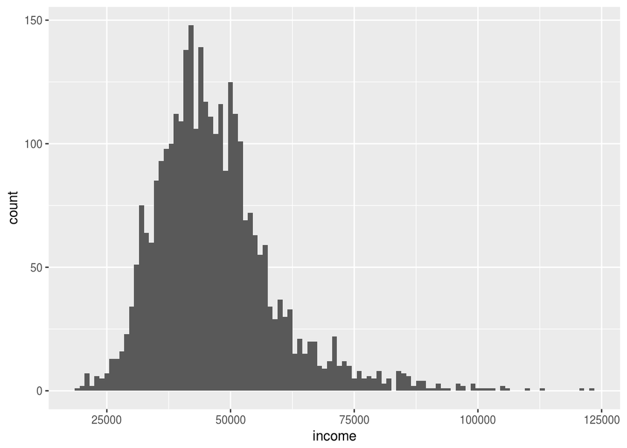

```r
#median_state_income <- ddply(county_df,.(State),summarize,median_income=mean(Income, na.rm=TRUE))

#median_state_income

#Histogram
 ggplot(county_df,aes(x=county_df$Income)) + geom_histogram(binwidth=1000) + labs(x= "income")
```

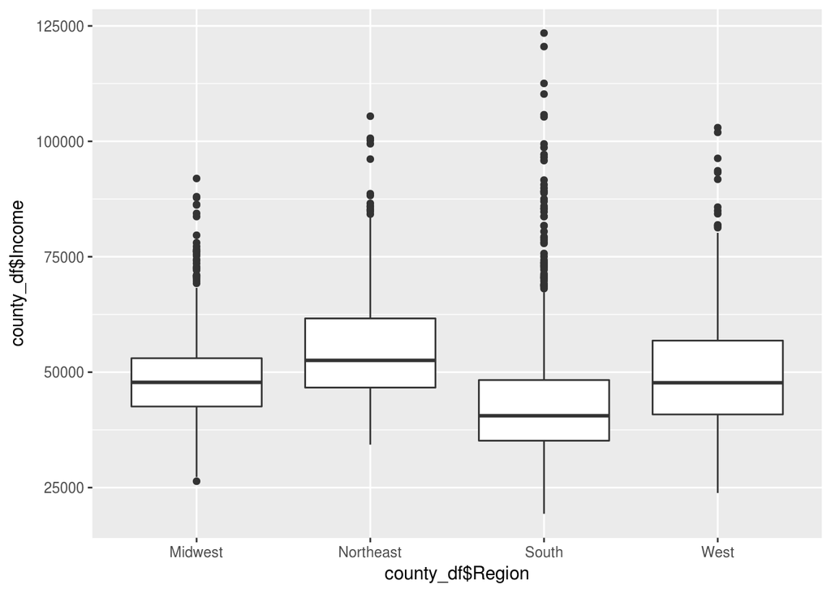

```r
#boxplot
 ggplot(county_df,aes(y=county_df$Income, x = county_df$Region)) + geom_boxplot()
```

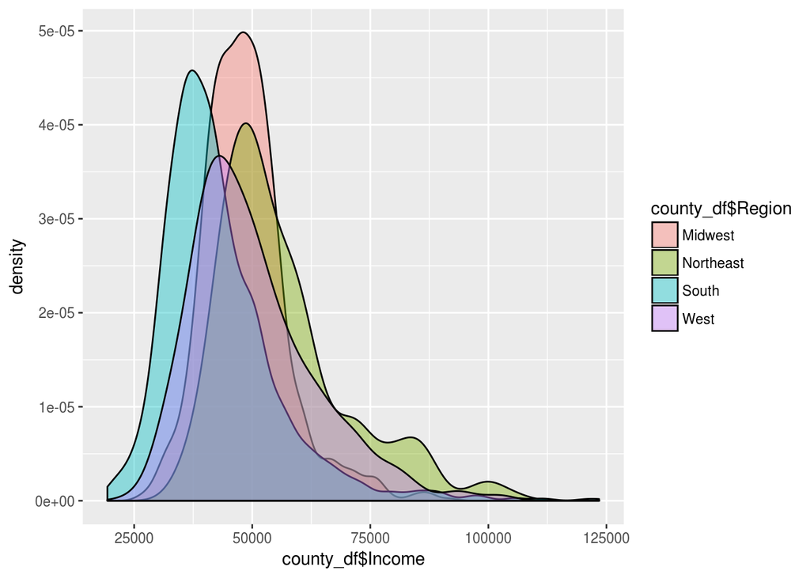

```r
 #+ scale_y_continuous(name = "Meudian Income", breaks = seq(0, 100000, 10000))

#Kernal Density Plot
 ggplot(county_df,aes(x=county_df$Income, fill = county_df$Region)) + geom_density(alpha = 0.4)
```

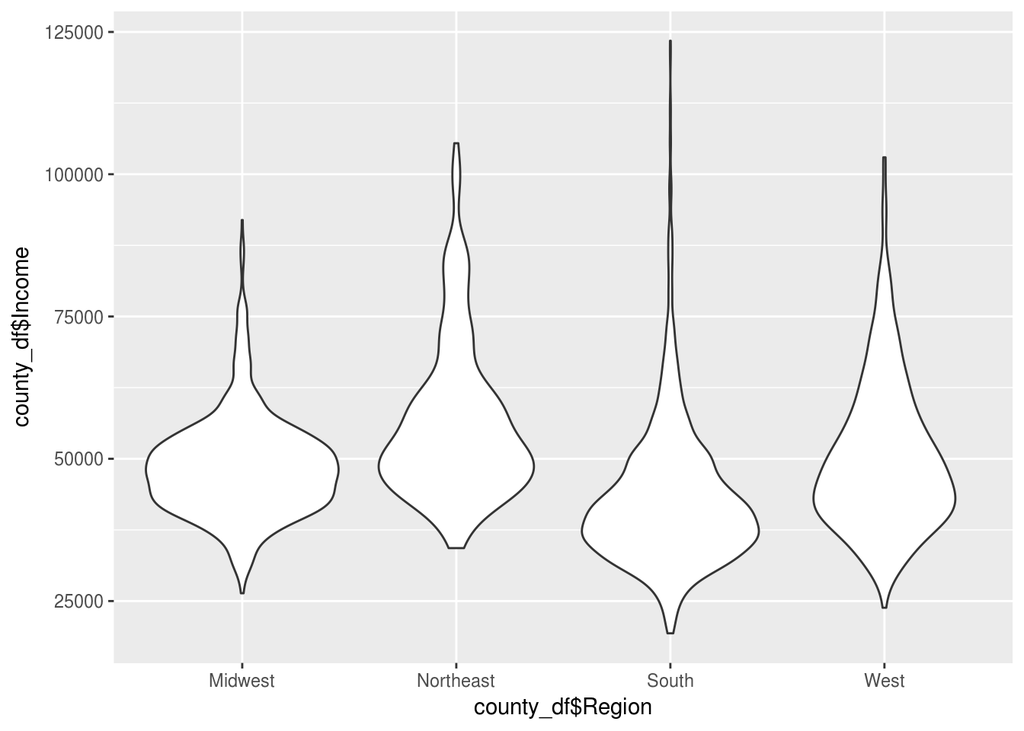

```r
#Violin Plot
 ggplot(county_df, aes(y=county_df$Income, x = county_df$Region)) + geom_violin()
```

### Problem 3 - Histogram of total population

Create a histogram of total population for counties in the US.

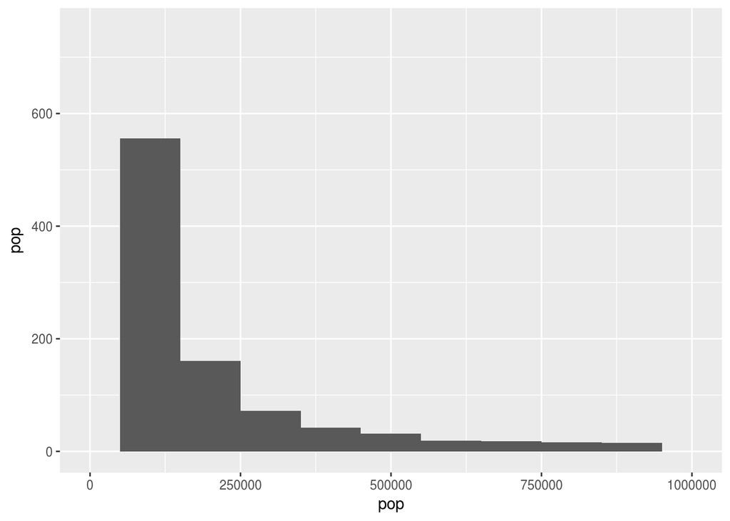

```r
ggplot(county_df,aes(x = TotalPop)) + geom_histogram(binwidth = 100000) + scale_x_continuous(name = "pop", limits=c(0, 1000000)) +scale_y_continuous(name = "pop", limits=c(0, 750))
```

Repeat the histogram about but make the following style changes to the plot.

- Add a title such as “Distribution of population for US counties”
- Change y-axis label to “Number of counties”
- Change x-axis label to “Total Population”
- Change the colors of the bars to something other than the default black

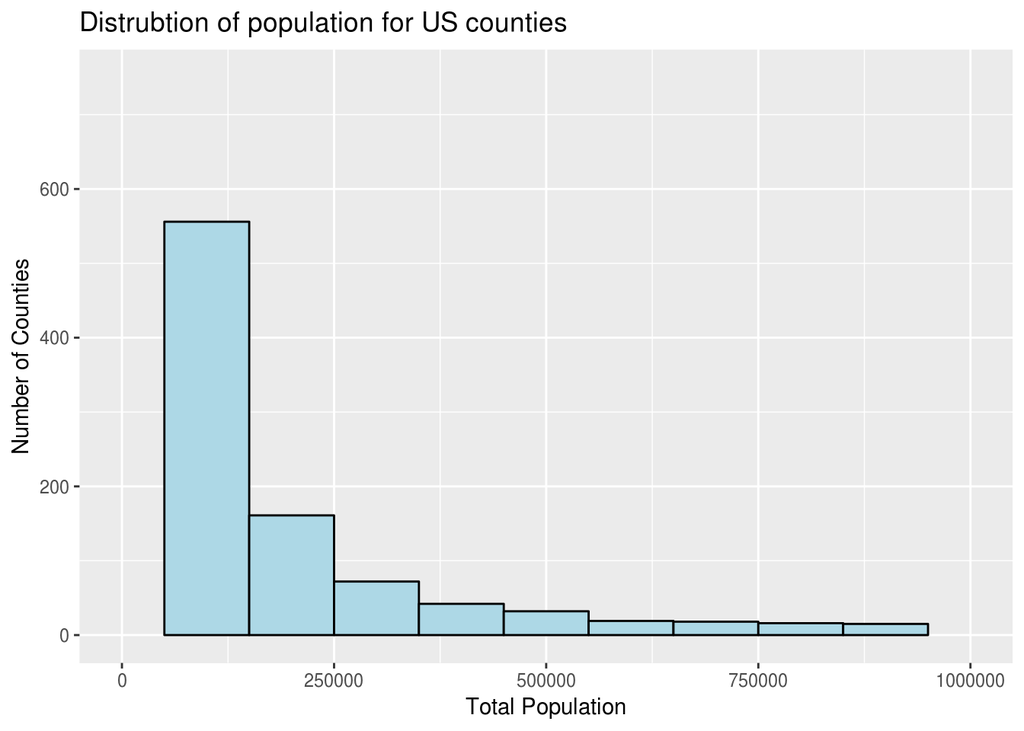

```r
ggplot(county_df,aes(x = TotalPop)) + geom_histogram(binwidth = 100000,colour = "black", fill = "lightblue") + scale_x_continuous(name = "Total Population", limits=c(0, 1000000)) +scale_y_continuous(name = "Number of Counties", limits=c(0, 750)) +ggtitle("Distrubtion of population for US counties")
```

**Hacker Extra** - Also create a kernel density plot overlaid on a histogram of Income.

Repeat the histogram but only for counties with less than 2.5 million people.

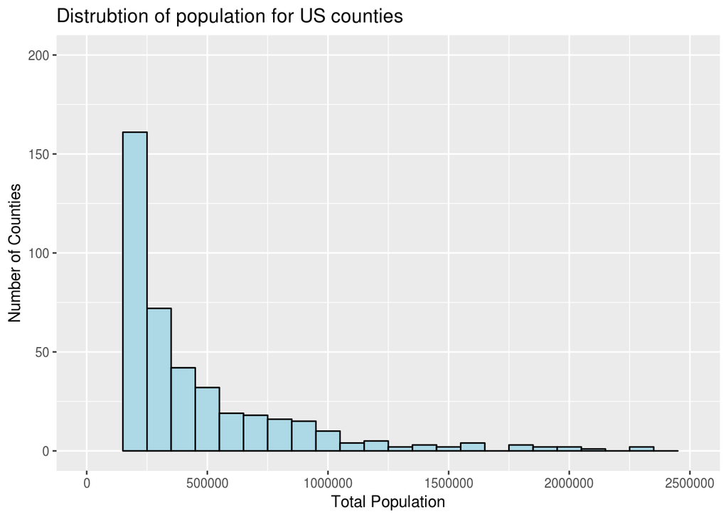

```r
ggplot(county_df[county_df$TotalPop < 2500000,],aes(x = TotalPop)) + geom_histogram(binwidth = 100000,colour = "black", fill = "lightblue") + scale_x_continuous(name = "Total Population", limits=c(0, 2500000)) +scale_y_continuous(name = "Number of Counties", limits=c(0, 200)) +ggtitle("Distrubtion of population for US counties")
```